# Lixiviação do Nitrogênio

Helio de Souza Junior,[^1] PG:55679

09/04/2025

Trabalho de avaliação elaborado durante a disciplina DAG4062 – Métodos Estatísticos, ministrado pelo Prof. Dr. Carlos Scapim, como instrumento para fixação de conhecimento e obtenção de nota.

## Introdução

Este relatório apresenta uma análise estatística dos dados de lixiviação de nitrogênio em um experimento fatorial 2³ com blocos casualizados. Os fatores avaliados foram:

- **A**: pH do solo (A1 = original, A2 = corrigido)
- **B**: tipo de ureia (B1 = ureia comum, B2 = ureia com cobertura)
- **C**: dose de ureia (C1 = dose baixa, C2 = dose alta)

## Organizaçao dos Dados

Foram realizadas 3 repetições por tratamento, totalizando 24 observações.

```r
# Dados do experimento
bloco <- rep(1:3, 8)
A <- rep(c("A1", "A1", "A1", "A1", "A2", "A2", "A2", "A2"), each = 3)
B <- rep(c("B1", "B1", "B2", "B2", "B1", "B1", "B2", "B2"), each = 3)
C <- rep(c("C1", "C2", "C1", "C2", "C1", "C2", "C1", "C2"), each = 3)

resposta <- c(
  22.65, 23.82, 20.96,
  57.11, 49.35, 35.97,
  15.46, 11.14, 15.10,
  35.84, 15.67, 21.53,
  8.94, 7.65, 9.94,
  18.02, 22.51, 22.00,
  6.31, 5.68, 4.99,
  13.15, 4.89, 7.05
)

dados <- data.frame(
  Bloco = factor(bloco),
  A = factor(A),
  B = factor(B),
  C = factor(C),
  N_Lixiviado = resposta
)

head(dados)
```

```
##   Bloco  A  B  C N_Lixiviado
## 1     1 A1 B1 C1       22.65
## 2     2 A1 B1 C1       23.82
## 3     3 A1 B1 C1       20.96
## 4     1 A1 B1 C2       57.11
## 5     2 A1 B1 C2       49.35
## 6     3 A1 B1 C2       35.97
```

## Modelo Estatístico

O modelo estatístico adotado para a análise do experimento fatorial $2 \times 2 \times 2$, em um delineamento em blocos casualizados

$$Y_{ijkl} = \mu + B_l + A_i + B_j + C_k + (AB)_{ij} + (AC)_{ik} +
(BC)_{jk} + (ABC)_{ijk} + \varepsilon_{ijkl}$$

**Onde:**

- $Y_{ijkl}$: valor observado da resposta (ex: perda por lixiviação de nitrogênio);
- $\mu$: média geral;
- $B_l$: efeito do $l$-ésimo bloco ($l = 1, 2, 3$);
- $A_i$: efeito do fator A (pH do solo);
- $B_j$: efeito do fator B (tipo de ureia);
- $C_k$: efeito do fator C (dose de ureia);
- $(AB)_{ij}$: interação entre os fatores A e B;
- $(AC)_{ik}$: interação entre os fatores A e C;
- $(BC)_{jk}$: interação entre os fatores B e C;
- $(ABC)_{ijk}$: interação tripla entre A, B e C;
- $\varepsilon_{ijkl}$: erro aleatório, assumido $\sim N(0, \sigma^2)$.

## Analíse de Variância (ANOVA)

```r
# Modelo com interacao tripla e blocos
modelo <- aov(N_Lixiviado ~ Bloco + A * B * C, data = dados)

# Resumo da ANOVA
summary(modelo)
```

```
##             Df Sum Sq Mean Sq F value   Pr(>F)
## Bloco        2  123.2    61.6   2.219   0.1455
## A            1 1559.6  1559.6  56.169 2.90e-06 ***
## B            1  841.5   841.5  30.305 7.75e-05 ***
## C            1  943.1   943.1  33.967 4.38e-05 ***
## A:B          1   96.5    96.5   3.476   0.0834 .
## A:C          1  161.4   161.4   5.811   0.0302 *
## B:C          1  213.3   213.3   7.682   0.0150 *
## A:B:C        1   10.4    10.4   0.373   0.5511
## Residuals   14  388.7    27.8
## ---
## Signif. codes:  0 '***' 0.001 '**' 0.01 '*' 0.05 '.' 0.1 ' ' 1
```

## Médias dos Tratamentos

```r
# Medias por combinacao de fatores
aggregate(N_Lixiviado ~ A + B + C, data = dados, mean)
```

```
##    A  B  C N_Lixiviado
## 1 A1 B1 C1   22.476667
## 2 A2 B1 C1    8.843333
## 3 A1 B2 C1   13.900000
## 4 A2 B2 C1    5.660000
## 5 A1 B1 C2   47.476667
## 6 A2 B1 C2   20.843333
## 7 A1 B2 C2   24.346667
## 8 A2 B2 C2    8.363333
```

## Visualização Gráfica

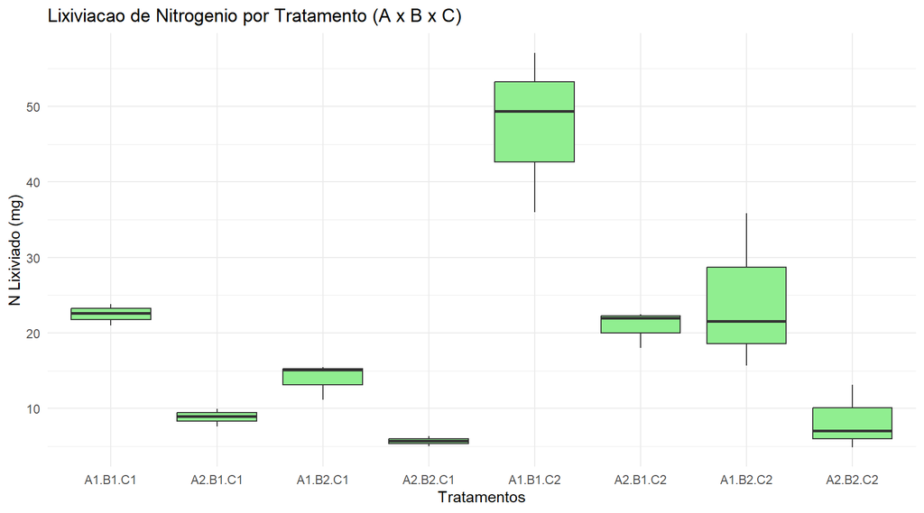

```r
library(ggplot2)

ggplot(dados, aes(x = interaction(A,B,C), y = N_Lixiviado)) +
  geom_boxplot(fill = "lightgreen") +
  labs(
    title = "Lixiviacao de Nitrogenio por Tratamento (A x B x C)",
    x = "Tratamentos",
    y = "N Lixiviado (mg)"
  ) +
  theme_minimal()
```

## Hipóteses Estatísticas

As hipóteses nulas e alternativas para cada efeito no modelo fatorial $2 \times 2 \times 2$, com blocos, são:

### Efeitos principais:

- **Fator A (tipo de solo):**

  $$\begin{cases}
  H_0: A_1 = A_2 \quad \text{(não há efeito do tipo de solo)} \\
  H_1: A_1 \ne A_2 \quad \text{(há efeito do tipo de solo)}
  \end{cases}$$
- **Fator B (tipo de ureia):**

  $$\begin{cases}
  H_0: B_1 = B_2 \quad \text{(não há efeito do tipo de ureia)} \\
  H_1: B_1 \ne B_2 \quad \text{(há efeito do tipo de ureia)}
  \end{cases}$$
- **Fator C (dose de ureia):**

  $$\begin{cases}
  H_0: C_1 = C_2 \quad \text{(não há efeito da dose de ureia)} \\
  H_1: C_1 \ne C_2 \quad \text{(há efeito da dose de ureia)}
  \end{cases}$$

### Interações:

- **Interação A × B:**

  $$\begin{cases}
  H_0: (AB)_{ij} = 0 \quad \text{(não há interação entre solo e ureia)} \\
  H_1: (AB)_{ij} \ne 0 \quad \text{(há interação entre solo e ureia)}
  \end{cases}$$
- **Interação A × C:**

  $$\begin{cases}
  H_0: (AC)_{ik} = 0 \quad \text{(não há interação entre solo e dose)} \\
  H_1: (AC)_{ik} \ne 0 \quad \text{(há interação entre solo e dose)}
  \end{cases}$$
- **Interação B × C:**

  $$\begin{cases}
  H_0: (BC)_{jk} = 0 \quad \text{(não há interação entre ureia e dose)} \\
  H_1: (BC)_{jk} \ne 0 \quad \text{(há interação entre ureia e dose)}
  \end{cases}$$
- **Interação A × B × C:**

  $$\begin{cases}
  H_0: (ABC)_{ijk} = 0 \quad \text{(não há interação tripla entre os
  fatores)} \\
  H_1: (ABC)_{ijk} \ne 0 \quad \text{(há interação tripla entre os
  fatores)}
  \end{cases}$$

## Diferença Mínima Significativa (DMS)

A fórmula utilizada é:

$$DMS = t_{(\alpha, \text{GLres})} \cdot \sqrt{2 \cdot
\dfrac{QM_{res}}{n}}$$

### Cálculo:

Duas médias diferem significativamente se:

$$|\bar{Y}_i - \bar{Y}_j| > DMS$$

## Pressupostos

A ANOVA depende do atendimento dos seguintes pressupostos:

1. **Normalidade dos Erros**
   - Os resíduos do modelo devem seguir uma distribuição normal.
   - Testes: Shapiro-Wilk, histograma, QQ-plot.
2. **Homogeneidade das Variâncias (Homoscedasticidade)**
   - A variância dos erros deve ser constante entre os grupos.
   - Testes: Bartlett, Levene; gráfico de resíduos vs. valores ajustados.
3. **Independência dos Erros**
   - Os resíduos devem ser independentes entre si.
   - Verificado pelo delineamento experimental e ordem de coleta.
4. **Aditividade dos Efeitos**
   - Supõe-se que os efeitos principais e interações se somam linearmente.

Caso algum desses pressupostos não seja atendido, pode-se considerar transformações nos dados ou o uso de métodos não paramétricos.

## Conclusão

- **Fatores significativos** (p < 0.05) indicam influencia estatistica na lixiviacao de nitrogenio.
- Em que:
  - **Doses maiores (C2)** resultem em mais perdas.
  - **Ureia com cobertura (B2)** apresente menor lixiviacao.
  - **pH corrigido (A2)** reduza a lixiviacao de nitrogenio.

Analises adicionais podem ser feitas com testes de comparacao de medias (Tukey) e graficos de interacao, conforme necessidade.

## Fórmulas Gerais da Análise de Variância (ANOVA) - Só deixei aqui para me ajudar nos exercícios

Fórmulas gerais para o cálculo das somas de quadrados em um experimento fatorial $2 \times 2 \times 2$, com blocos ao acaso e uma variável resposta contínua.

### Soma de Quadrados Total (SQT)

$$SQ_{Total} = \sum_{i,j,k,l} Y_{ijkl}^2 - \frac{(\sum Y_{ijkl})^2}{n}$$

### Soma de Quadrados do Bloco (SQB)

$$SQ_{Bloco} = \frac{1}{abc} \sum_{l=1}^{r} \left( Y_{\cdot\cdot\cdot l}
\right)^2 - \frac{(\sum Y_{ijkl})^2}{n}$$

### Soma de Quadrados do Fator A

$$SQ_{A} = \frac{1}{bcr} \sum_{i=1}^{a} \left( Y_{i\cdot\cdot\cdot}
\right)^2 - \frac{(\sum Y_{ijkl})^2}{n}$$

### Soma de Quadrados do Fator B

$$SQ_{B} = \frac{1}{acr} \sum_{j=1}^{b} \left( Y_{\cdot j\cdot\cdot}
\right)^2 - \frac{(\sum Y_{ijkl})^2}{n}$$

### Soma de Quadrados do Fator C

$$SQ_{C} = \frac{1}{abr} \sum_{k=1}^{c} \left( Y_{\cdot\cdot k\cdot}
\right)^2 - \frac{(\sum Y_{ijkl})^2}{n}$$

### Soma de Quadrados da Interação AB

$$SQ_{AB} = \frac{1}{cr} \sum_{i=1}^{a} \sum_{j=1}^{b} \left(
Y_{ij\cdot\cdot} \right)^2 - SQ_A - SQ_B - \frac{(\sum Y_{ijkl})^2}{n}$$

### Soma de Quadrados da Interação AC

$$SQ_{AC} = \frac{1}{br} \sum_{i=1}^{a} \sum_{k=1}^{c} \left( Y_{i\cdot
k\cdot} \right)^2 - SQ_A - SQ_C - \frac{(\sum Y_{ijkl})^2}{n}$$

### Soma de Quadrados da Interação BC

$$SQ_{BC} = \frac{1}{ar} \sum_{j=1}^{b} \sum_{k=1}^{c} \left( Y_{\cdot
jk\cdot} \right)^2 - SQ_B - SQ_C - \frac{(\sum Y_{ijkl})^2}{n}$$

### Soma de Quadrados da Interação ABC

$$SQ_{ABC} = \frac{1}{r} \sum_{i=1}^{a} \sum_{j=1}^{b} \sum_{k=1}^{c}
\left( Y_{ijk\cdot} \right)^2 - SQ_{AB} - SQ_{AC} - SQ_{BC} - SQ_A -
SQ_B - SQ_C - \frac{(\sum Y_{ijkl})^2}{n}$$

### Soma de Quadrados do Erro (SQE)

$$SQ_{Erro} = SQ_{Total} - SQ_{Bloco} - SQ_A - SQ_B - SQ_C - SQ_{AB} -
SQ_{AC} - SQ_{BC} - SQ_{ABC}$$

## Graus de Liberdade (GL)

Os graus de liberdade associados a cada fonte de variação no experimento fatorial $2 \times 2 \times 2$ com blocos são definidos da seguinte forma: